# Part II - Proper Loans Data Exploration

## by Koketso Mangwale

## Investigative Overview

In this project we will explore and analyse the loans data from Prosper in Q4 2005 to Q1 2014 in the USA. The dataset is made up of 113 937 loans and 81 features.

## Dataset Overview

The dataset is about historic loans data from Prosper. It is made up of the borrower credit profile, location, employment, income, payment history, loan information, borrower's credit score change over time as well as loan investment information.

There are 113 937 loans with 81 features. There is a small amount of features that will be chosen for this analysis. Each loan observation is uniquely identified by a listing key and the date that each listing was created ranges from November 9, 2005 to March 10, 2014.

### Distribution of Borrower APR and Interest Rates

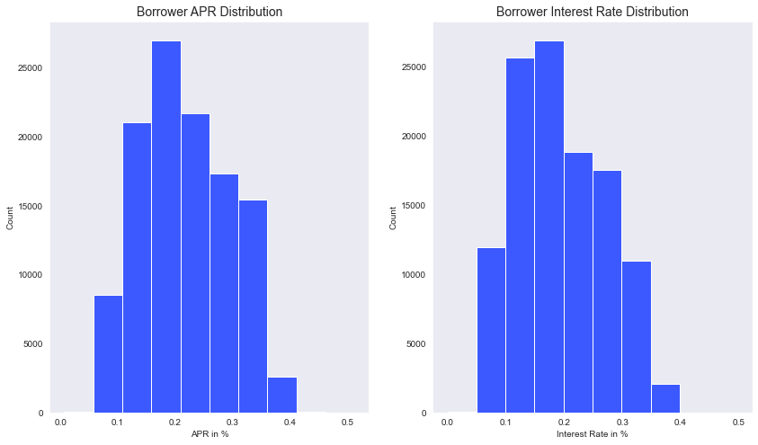

**Findings:**

- The a data is right skewed.
- The median APR and median interest rate are slightly lower than the average. The typical APR and interest rate is about 0.2%.
- A high density of borrowers have an APR of about 0.2% and interest rates of 0.18%
- This is followed by a density of borrowers with an APR of between 0.2% and 0.25% and interest rates between 0.1% and 0.15%
- About 2 500 borrowers have APR's and interest rates above 0.35%.

### Distribution of Loans with Verifiable Income

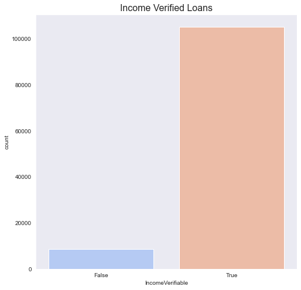

**Findings:**

- There is a high frequency of loans that are income verified./Most of the loans are income verified
- More than 100 000 loans are income verified.

### Distribution of Debt to Income (DTI) Ratio

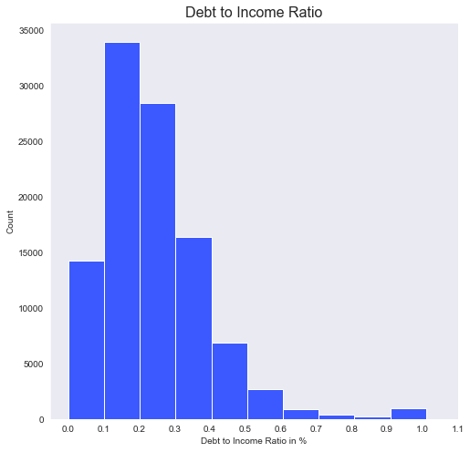

**Findings:**

- The data is right skewed or positively skewed and the typical borrower DTI is 20%.
- The average DTI is slightly larger than the median.
- A high density of borrowers have an DTI ratio between 10% and 20%
- This is followed by a density of borrowers with an DTI ratio between 20% and 30%

### Loan Status

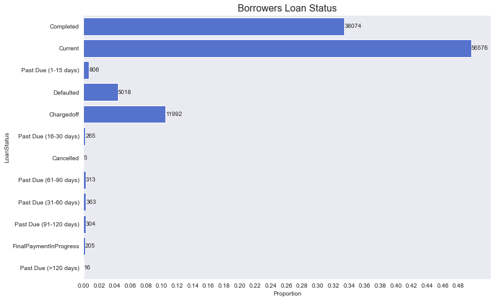

**Findings:**

- About 4% of the loans are in default.

### Borrower APR vs Interest Rate

[figure not shown]

### Prosper Score vs BorrowerAPR

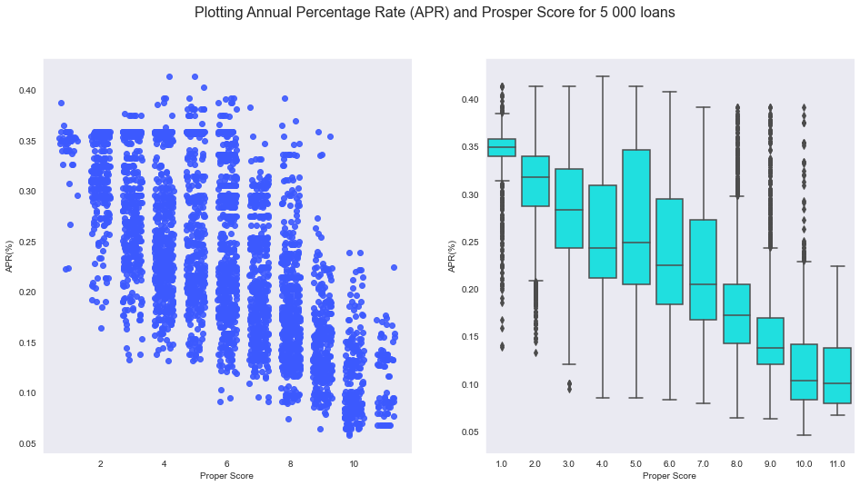

**Findings:**

- As the the prosper score gets higher, the median Annual % Rate lowers.
- There is outlier AP Rates with prosper scores 1 - 3 and 8 - 10.
- There is more variation with borrowers a prosper score of 5.
- The box plot above indicates that loan prosper score does have an influence on Annual % Rate.

### Borrower APR and Interest Rate by Employment Status

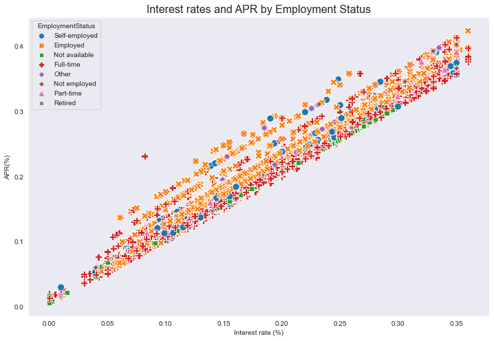

**Findings:**

- Part-time borrowers have the least variability in borrower rate and APR. Is this because they might be considered high risk?
- Borrowers with the most variability are employed and full-time as shown in orange and red respectively.

### Borrower APR and Score by Homeownership

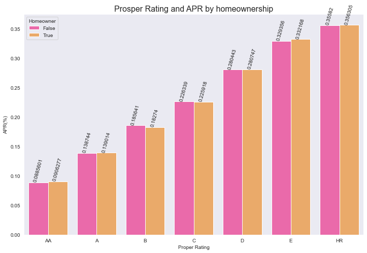

**Findings:**

- Homeowners and non-homeowner seem to have the same APR accross all borrower types

### Borrower APR and Credit Grade by Term

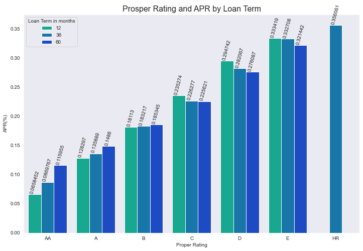

**Findings:**

- A+, A and B Grades(low-risk borrowers) have all their term loans at the lowest AP rates
- High-risk borrowers only have medium-term loans at a high interest rate.
- C, D and E-grade borrowers(medium-risk) have short-term loans at the higher AP rates. Short and medium term are at a higher AP rate than long-term loans.

## Conclusions

**Prosper Loan Portfolio has disclosed low annual percentages and interest rates and most borrowers's income is verified and they have a low DTI ratio which are good indicators that most borrowers effectively manage to make their monthly repayments. Prosper is extending loans to borrowers who can afford to pay them.**

**From the negative correlaton of Prosper Score and APR, a potential borrower with a high score will get a low APR. Prosper has a low proportion of high risk borrowers. The higher the borrower risk there is reduced flexibilty in loan terms but still at high APR rates. In addition, the loan portfolio has a low default rate of 4%.**